# W241 Problem Set 2

Yang Yang Qian

# 1. FE exercise 3.6

The Clingingsmith, Khwaja, and Kremer study discussed in section 3.5 may be be used to test the sharp null hypothesis that winning the visa lottery for the pilgrimage to Mecca had no effect on the views of Pakistani Muslims toward people from other countries. Assume that the Pakistani authorities assigned visas using complete random assignment.

## 1.a.

Conduct 10,000 simulated random assignments under the sharp null hypothesis. (Don’t just copy the code from the async, think about how to write this yourself.)

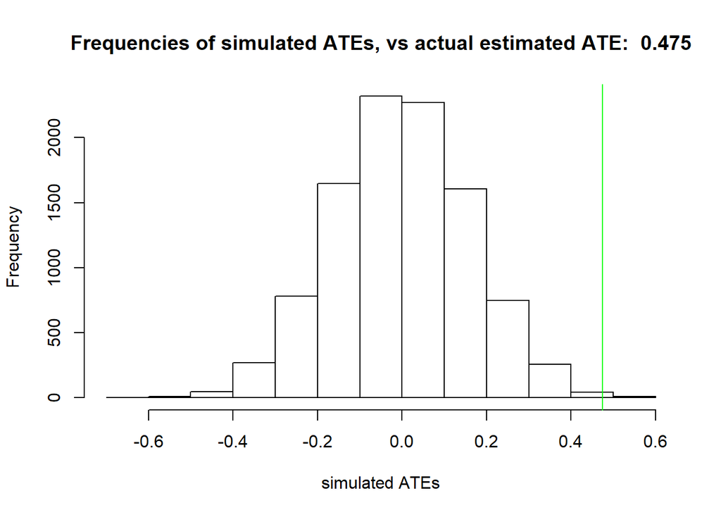

```r
# conducting 1 simulated random assignment under the sharp null hypothesis (e.g. matters not if person won visa, their view would not have changed)
# so we flip a fair coin for each person in population, 1 = won visa (treatment), 0 = did not win visa (control)
# ... and we don't change the views, because we are assuming that assignment to win or not win a visa would not have changed it at all

# set.seed(87542)
# q1$d3.6 <- q1$d3.6[, success.q1.a := replicate(nrow(q1$d3.6), rbinom(1,1,0.5))]
# q1$m2 <- q1$d3.6[,lm(views ~ success.q1.a)]
# q1$ate.q1.a <- q1$m2$coefficients[2]


# to conduct 10,000 simulated random assignments under the sharp null hypothesis, just need to create a simulate study function and call it 10,000 times
# then get a distribution of ATEs
set.seed(87542)
q1$sim.study <- function() {
    q1$d3.6 <- q1$d3.6[, success.q1.a := replicate(nrow(q1$d3.6), rbinom(1,1,0.5))]
    q1$m2 <- q1$d3.6[,lm(views ~ success.q1.a)]
    q1$ate.q1.a <- q1$m2$coefficients[2]
    return(q1$ate.q1.a)
}
q1$sim.results <- replicate(10000, q1$sim.study())
hist(q1$sim.results, xlab="simulated ATEs", main=paste("Frequencies of simulated ATEs, vs actual estimated ATE: ",round(q1$ate,3)))
abline(v=q1$ate,col="green")
```

## 1.b.

How many of the simulated random assignments generate an estimated ATE that is at least as large as the actual estimate of the ATE?

**about 15**

```r
data.table(q1$sim.results)[,sim.ate.as.large.as.actual.ate:=(q1$sim.results >= q1$ate)][,.N,by=sim.ate.as.large.as.actual.ate]
```

```
##    sim.ate.as.large.as.actual.ate    N
## 1:                          FALSE 9985
## 2:                           TRUE   15
```

## 1.c.

What is the implied one-tailed p-value?

**implied one-tailed p-value is about 0.0015**

```r
mean(q1$sim.results > q1$ate)
```

```
## [1] 0.0015
```

## 1.d.

How many of the simulated random assignments generate an estimated ATE that is at least as large *in absolute value* as the actual estimate of the ATE?

**about 31, roughly double that of the one-tailed test**

```r
data.table(q1$sim.results)[,sim.ate.abs.as.large.as.actual.ate:=(abs(q1$sim.results) >= abs(q1$ate))][,.N,by=sim.ate.abs.as.large.as.actual.ate]
```

```
##    sim.ate.abs.as.large.as.actual.ate    N
## 1:                              FALSE 9969
## 2:                               TRUE   31
```

## 1.e.

What is the implied two-tailed p-value?

**implied two-tailed p-value is about 0.0031**

```r
mean(abs(q1$sim.results) > abs(q1$ate))
```

```
## [1] 0.0031
```

```r
# or
mean(q1$sim.results > q1$ate) * 2
```

```
## [1] 0.003
```

# 2.FE exercise 3.8

If you’re interested, or would like more clarification, the published version of the paper is in the repository.

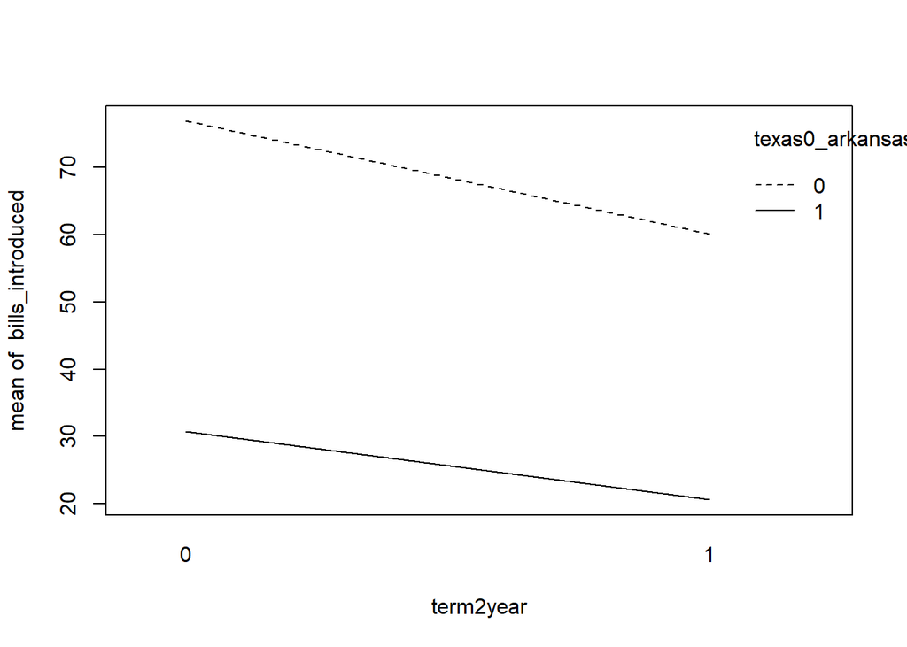

```r
library(foreign)
library(data.table)
q2 <- {}
q2$d3.8 <- data.table( read.dta("./data/Titiunik.2010.dta") )
# head(q2$d3.8)
# summary(q2$d3.8)
# str(q2$d3.8)
# hist(q2$d3.8$term2year)
# hist(q2$d3.8$bills_introduced)
# hist(q2$d3.8$texas0_arkansas1)
# q2$d3.8[texas0_arkansas1==0,plot(bills_introduced ~ term2year,main="Texas")]
# q2$d3.8[texas0_arkansas1==1,plot(bills_introduced ~ term2year,main="Arkansas")]
q2$d3.8[,interaction.plot(term2year,texas0_arkansas1,bills_introduced)]
```